# Examen parcial 2 de Models Lineals

Laura Julià Melis

9/1/2018

## PROBLEMA 2

Obtenció de les dades:

```r
linthurst <- read.table("LINTHALL.DTA", col.names=c("loc","type","biomass","H2S","salinity","Eh7", "pH","BUF","P","K","Ca","Mg","Na","Mn", "Zn","Cu","NH4"))

linthurst <-linthurst[, -c(1,2)]
```

### APARTAT A

##### Regressio mínim-quadràtica ordinària:

```r
g <- lm(biomass ~ ., data = linthurst)
summary(g)
```

```
##
## Call:
## lm(formula = biomass ~ ., data = linthurst)
##
## Residuals:
##     Min      1Q  Median      3Q     Max
## -673.61 -148.68  -29.16  160.87 1012.18
##
## Coefficients:
##               Estimate Std. Error t value Pr(>|t|)
## (Intercept)  2.910e+03  3.413e+03   0.853  0.40062
## H2S          4.290e-01  2.998e+00   0.143  0.88717
## salinity    -2.398e+01  2.617e+01  -0.916  0.36678
## Eh7          2.553e+00  2.012e+00   1.269  0.21430
## pH           2.425e+02  3.342e+02   0.726  0.47361
## BUF         -6.902e+00  1.238e+02  -0.056  0.95592
## P           -1.702e+00  2.640e+00  -0.645  0.52409
## K           -1.047e+00  4.824e-01  -2.170  0.03808 *
## Ca          -1.161e-01  1.256e-01  -0.924  0.36293
## Mg          -2.802e-01  2.745e-01  -1.021  0.31540
## Na           4.451e-03  2.472e-02   0.180  0.85834
## Mn          -1.679e+00  5.373e+00  -0.312  0.75687
## Zn          -1.879e+01  2.178e+01  -0.863  0.39503
## Cu           3.452e+02  1.121e+02   3.080  0.00441 **
## NH4         -2.705e+00  3.238e+00  -0.835  0.41007
## ---
## Signif. codes:  0 '***' 0.001 '**' 0.01 '*' 0.05 '.' 0.1 ' ' 1
##
## Residual standard error: 350.8 on 30 degrees of freedom
## Multiple R-squared:  0.8074, Adjusted R-squared:  0.7175
## F-statistic: 8.983 on 14 and 30 DF,  p-value: 3.066e-07
```

Les variables regressores amb un coeficient de regressió significatiu són K i Cu.

### APARTAT B

##### B1. Millor model segons “regsubsets”:

```r
library(leaps)
b <- regsubsets(biomass ~ ., data = linthurst)
rs <- summary(b)
rs
```

```
## Subset selection object
## Call: regsubsets.formula(biomass ~ ., data = linthurst)
## 14 Variables  (and intercept)
##          Forced in Forced out
## H2S          FALSE      FALSE
## salinity     FALSE      FALSE
## Eh7          FALSE      FALSE
## pH           FALSE      FALSE
## BUF          FALSE      FALSE
## P            FALSE      FALSE
## K            FALSE      FALSE
## Ca           FALSE      FALSE
## Mg           FALSE      FALSE
## Na           FALSE      FALSE
## Mn           FALSE      FALSE
## Zn           FALSE      FALSE
## Cu           FALSE      FALSE
## NH4          FALSE      FALSE
## 1 subsets of each size up to 8
## Selection Algorithm: exhaustive
##          H2S salinity Eh7 pH  BUF P   K   Ca  Mg  Na  Mn  Zn  Cu  NH4
## 1  ( 1 ) " " " "      " " "*" " " " " " " " " " " " " " " " " " " " "
## 2  ( 1 ) " " " "      " " "*" " " " " " " " " "*" " " " " " " " " " "
## 3  ( 1 ) " " " "      " " "*" " " " " " " "*" "*" " " " " " " " " " "
## 4  ( 1 ) " " " "      " " "*" " " " " " " "*" "*" " " " " " " "*" " "
## 5  ( 1 ) " " "*"      " " " " " " " " "*" " " " " " " " " "*" "*" "*"
## 6  ( 1 ) " " "*"      "*" " " " " " " "*" " " " " " " " " "*" "*" "*"
## 7  ( 1 ) " " "*"      "*" " " " " " " "*" " " "*" " " " " "*" "*" "*"
## 8  ( 1 ) " " " "      "*" "*" " " "*" "*" "*" "*" " " " " " " "*" "*"
```

El millor model de només tres variables regressores serà amb pH, Ca i Mg.

##### B2. Millor model segons el valor AIC:

```r
sg <- step(g)
```

```
## Start:  AIC=539.18
## biomass ~ H2S + salinity + Eh7 + pH + BUF + P + K + Ca + Mg +
##     Na + Mn + Zn + Cu + NH4
##
##            Df Sum of Sq     RSS    AIC
## - BUF       1       382 3692616 537.18
## - H2S       1      2520 3694754 537.21
## - Na        1      3989 3696223 537.23
## - Mn        1     12014 3704248 537.32
## - P         1     51136 3743370 537.80
## - pH        1     64826 3757059 537.96
## - NH4       1     85902 3778135 538.21
## - Zn        1     91645 3783878 538.28
## - salinity  1    103349 3795582 538.42
## - Ca        1    105046 3797279 538.44
## - Mg        1    128310 3820543 538.72
## <none>                  3692233 539.18
## - Eh7       1    198105 3890338 539.53
## - K         1    579405 4271638 543.74
## - Cu        1   1167282 4859515 549.54
##
## Step:  AIC=537.18
## biomass ~ H2S + salinity + Eh7 + pH + P + K + Ca + Mg + Na +
##     Mn + Zn + Cu + NH4
##
##            Df Sum of Sq     RSS    AIC
## - H2S       1      2172 3694788 535.21
## - Na        1      5685 3698301 535.25
## - Mn        1     14450 3707066 535.36
## - P         1     51990 3744606 535.81
## - Zn        1     95426 3788042 536.33
## - salinity  1    104506 3797122 536.44
## - Ca        1    127873 3820489 536.72
## - Mg        1    135127 3827743 536.80
## <none>                  3692616 537.18
## - pH        1    168630 3861245 537.19
## - NH4       1    171691 3864307 537.23
## - Eh7       1    199359 3891975 537.55
## - K         1    580616 4273232 541.75
## - Cu        1   1167368 4859984 547.54
```

[output cut: 80 more lines]

```
## - pH    1    640673 4552715 534.61
## - Cu    1   1154766 5066808 539.42
##
## Step:  AIC=529.58
## biomass ~ pH + K + Ca + Mg + Zn + Cu + NH4
##
##        Df Sum of Sq     RSS    AIC
## <none>              4071624 529.58
## - NH4   1    212313 4283937 529.87
## - Zn    1    268728 4340352 530.46
## - K     1    394345 4465969 531.74
## - Mg    1    469550 4541174 532.49
## - Ca    1    499771 4571395 532.79
## - pH    1    701546 4773170 534.73
## - Cu    1   1023156 5094780 537.67
```

```r
summary(sg)
```

```
##
## Call:
## lm(formula = biomass ~ pH + K + Ca + Mg + Zn + Cu + NH4, data = linthurst)
##
## Residuals:
##     Min      1Q  Median      3Q     Max
## -597.97 -159.98  -45.85  172.50 1063.49
##
## Coefficients:
##              Estimate Std. Error t value Pr(>|t|)
## (Intercept) 465.86735  590.96290   0.788  0.43553
## pH          384.20942  152.16782   2.525  0.01599 *
## K            -0.76538    0.40432  -1.893  0.06620 .
## Ca           -0.17993    0.08443  -2.131  0.03979 *
## Mg           -0.27157    0.13147  -2.066  0.04592 *
## Zn          -17.98468   11.50877  -1.563  0.12664
## Cu          301.79306   98.97405   3.049  0.00422 **
## NH4          -2.79377    2.01134  -1.389  0.17313
## ---
## Signif. codes:  0 '***' 0.001 '**' 0.01 '*' 0.05 '.' 0.1 ' ' 1
##
## Residual standard error: 331.7 on 37 degrees of freedom
## Multiple R-squared:  0.7876, Adjusted R-squared:  0.7474
## F-statistic:  19.6 on 7 and 37 DF,  p-value: 1.126e-10
```

##### B3. Millor model segons el coeficient de determinació ajustat:

```r
summary(g)$adj.r.squared
```

```
## [1] 0.7175272
```

##### B4. Millor model segons el coeficient Cp:

```r
coef(b, 1:8)
```

```
## [[1]]
## (Intercept)          pH
##   -885.2105    409.8043
##
## [[2]]
##  (Intercept)           pH           Mg
## -239.8712376  386.5705254   -0.1750872
##
## [[3]]
##  (Intercept)           pH           Ca           Mg
## -580.6821288  671.6872828   -0.2492819   -0.2992221
##
## [[4]]
##  (Intercept)           pH           Ca           Mg           Cu
## -549.5415793  579.4733680   -0.2061855   -0.4159410  163.0242876
##
## [[5]]
## (Intercept)    salinity           K          Zn          Cu         NH4
## 3215.884367  -45.359139   -1.330847  -45.006323  360.011931   -4.712546
##
## [[6]]
## (Intercept)    salinity         Eh7           K          Zn          Cu
## 4410.069023  -51.774785    3.056642   -1.555147  -43.878380  386.184439
##         NH4
##   -4.536945
##
## [[7]]
##  (Intercept)     salinity          Eh7            K           Mg
## 4103.3649758  -42.3015049    3.0477617   -1.1723322   -0.1771701
##           Zn           Cu          NH4
##  -36.3361079  420.7392021   -4.7196811
##
## [[8]]
## (Intercept)         Eh7          pH           P           K          Ca
## 957.3237542   2.0601555 406.4613836  -2.9661960  -0.7931287  -0.1627173
##          Mg          Cu         NH4
##  -0.3286876 300.9938068  -2.9263908
```

### APARTAT C

##### C1. Selecció backward:

```r
step(g, scope=formula(g), direction="backward")
```

```
## Start:  AIC=539.18
## biomass ~ H2S + salinity + Eh7 + pH + BUF + P + K + Ca + Mg +
##     Na + Mn + Zn + Cu + NH4
##
##            Df Sum of Sq     RSS    AIC
## - BUF       1       382 3692616 537.18
## - H2S       1      2520 3694754 537.21
## - Na        1      3989 3696223 537.23
## - Mn        1     12014 3704248 537.32
## - P         1     51136 3743370 537.80
## - pH        1     64826 3757059 537.96
## - NH4       1     85902 3778135 538.21
## - Zn        1     91645 3783878 538.28
## - salinity  1    103349 3795582 538.42
## - Ca        1    105046 3797279 538.44
## - Mg        1    128310 3820543 538.72
## <none>                  3692233 539.18
## - Eh7       1    198105 3890338 539.53
## - K         1    579405 4271638 543.74
## - Cu        1   1167282 4859515 549.54
##
## Step:  AIC=537.18
## biomass ~ H2S + salinity + Eh7 + pH + P + K + Ca + Mg + Na +
##     Mn + Zn + Cu + NH4
##
##            Df Sum of Sq     RSS    AIC
## - H2S       1      2172 3694788 535.21
## - Na        1      5685 3698301 535.25
## - Mn        1     14450 3707066 535.36
## - P         1     51990 3744606 535.81
## - Zn        1     95426 3788042 536.33
## - salinity  1    104506 3797122 536.44
## - Ca        1    127873 3820489 536.72
## - Mg        1    135127 3827743 536.80
## <none>                  3692616 537.18
## - pH        1    168630 3861245 537.19
## - NH4       1    171691 3864307 537.23
## - Eh7       1    199359 3891975 537.55
## - K         1    580616 4273232 541.75
## - Cu        1   1167368 4859984 547.54
```

[output cut: 80 more lines]

```
## - pH    1    640673 4552715 534.61
## - Cu    1   1154766 5066808 539.42
##
## Step:  AIC=529.58
## biomass ~ pH + K + Ca + Mg + Zn + Cu + NH4
##
##        Df Sum of Sq     RSS    AIC
## <none>              4071624 529.58
## - NH4   1    212313 4283937 529.87
## - Zn    1    268728 4340352 530.46
## - K     1    394345 4465969 531.74
## - Mg    1    469550 4541174 532.49
## - Ca    1    499771 4571395 532.79
## - pH    1    701546 4773170 534.73
## - Cu    1   1023156 5094780 537.67
```

```
##
## Call:
## lm(formula = biomass ~ pH + K + Ca + Mg + Zn + Cu + NH4, data = linthurst)
##
## Coefficients:
## (Intercept)           pH            K           Ca           Mg
##    465.8674     384.2094      -0.7654      -0.1799      -0.2716
##          Zn           Cu          NH4
##    -17.9847     301.7931      -2.7938
```

Ens quedem amb les variables regressores pH, K, Ca, Mg, Zn, Cu i NH4. És el model amb menys variables, el mes simple.

##### C2. Selecció backward amb el criteri del test F:

```r
step(g, scope=formula(g), direction="backward", test="F")
```

```
## Start:  AIC=539.18
## biomass ~ H2S + salinity + Eh7 + pH + BUF + P + K + Ca + Mg +
##     Na + Mn + Zn + Cu + NH4
##
##            Df Sum of Sq     RSS    AIC F value   Pr(>F)
## - BUF       1       382 3692616 537.18  0.0031 0.955915
## - H2S       1      2520 3694754 537.21  0.0205 0.887169
## - Na        1      3989 3696223 537.23  0.0324 0.858337
## - Mn        1     12014 3704248 537.32  0.0976 0.756871
## - P         1     51136 3743370 537.80  0.4155 0.524095
## - pH        1     64826 3757059 537.96  0.5267 0.473614
## - NH4       1     85902 3778135 538.21  0.6980 0.410073
## - Zn        1     91645 3783878 538.28  0.7446 0.395029
## - salinity  1    103349 3795582 538.42  0.8397 0.366784
## - Ca        1    105046 3797279 538.44  0.8535 0.362932
## - Mg        1    128310 3820543 538.72  1.0425 0.315395
## <none>                  3692233 539.18
## - Eh7       1    198105 3890338 539.53  1.6096 0.214299
## - K         1    579405 4271638 543.74  4.7078 0.038077 *
## - Cu        1   1167282 4859515 549.54  9.4844 0.004407 **
## ---
## Signif. codes:  0 '***' 0.001 '**' 0.01 '*' 0.05 '.' 0.1 ' ' 1
##
## Step:  AIC=537.18
## biomass ~ H2S + salinity + Eh7 + pH + P + K + Ca + Mg + Na +
##     Mn + Zn + Cu + NH4
##
##            Df Sum of Sq     RSS    AIC F value   Pr(>F)
## - H2S       1      2172 3694788 535.21  0.0182 0.893450
## - Na        1      5685 3698301 535.25  0.0477 0.828493
## - Mn        1     14450 3707066 535.36  0.1213 0.729975
## - P         1     51990 3744606 535.81  0.4365 0.513715
## - Zn        1     95426 3788042 536.33  0.8011 0.377658
## - salinity  1    104506 3797122 536.44  0.8773 0.356170
## - Ca        1    127873 3820489 536.72  1.0735 0.308169
## - Mg        1    135127 3827743 536.80  1.1344 0.295063
## <none>                  3692616 537.18
## - pH        1    168630 3861245 537.19  1.4157 0.243151
## - NH4       1    171691 3864307 537.23  1.4414 0.239012
## - Eh7       1    199359 3891975 537.55  1.6736 0.205328
```

[output cut: 96 more lines]

```
##
## Step:  AIC=529.58
## biomass ~ pH + K + Ca + Mg + Zn + Cu + NH4
##
##        Df Sum of Sq     RSS    AIC F value   Pr(>F)
## <none>              4071624 529.58
## - NH4   1    212313 4283937 529.87  1.9293 0.173134
## - Zn    1    268728 4340352 530.46  2.4420 0.126638
## - K     1    394345 4465969 531.74  3.5835 0.066197 .
## - Mg    1    469550 4541174 532.49  4.2669 0.045918 *
## - Ca    1    499771 4571395 532.79  4.5416 0.039790 *
## - pH    1    701546 4773170 534.73  6.3751 0.015990 *
## - Cu    1   1023156 5094780 537.67  9.2977 0.004223 **
## ---
## Signif. codes:  0 '***' 0.001 '**' 0.01 '*' 0.05 '.' 0.1 ' ' 1
```

```
##
## Call:
## lm(formula = biomass ~ pH + K + Ca + Mg + Zn + Cu + NH4, data = linthurst)
##
## Coefficients:
## (Intercept)           pH            K           Ca           Mg
##    465.8674     384.2094      -0.7654      -0.1799      -0.2716
##          Zn           Cu          NH4
##    -17.9847     301.7931      -2.7938
```

##### C3.Selecció forward:

```r
g0 <-lm(biomass ~ 1,data= linthurst)

step(g0, scope=formula(g), direction="forward", test="F")
```

```
## Start:  AIC=585.3
## biomass ~ 1
##
##            Df Sum of Sq      RSS    AIC F value    Pr(>F)
## + pH        1  11490388  7680575 546.14 64.3294 4.433e-10 ***
## + BUF       1  10334661  8836302 552.45 50.2914 9.482e-09 ***
## + Ca        1   7934775 11236188 563.26 30.3658 1.875e-06 ***
## + NH4       1   7512383 11658580 564.92 27.7077 4.249e-06 ***
## + Zn        1   7474474 11696489 565.07 27.4785 4.566e-06 ***
## + Mg        1   2736601 16434363 580.37  7.1602   0.01050 *
## + P         1   2411755 16759208 581.25  6.1880   0.01682 *
## + Mn        1   2288888 16882075 581.58  5.8300   0.02008 *
## + H2S       1   2144105 17026858 581.96  5.4148   0.02475 *
## + Na        1   1419069 17751894 583.84  3.4374   0.07060 .
## <none>                  19170963 585.30
## + K         1    802872 18368091 585.38  1.8795   0.17750
## + salinity  1    204048 18966915 586.82  0.4626   0.50006
## + Cu        1    167165 19003798 586.91  0.3782   0.54179
## + Eh7       1     42847 19128116 587.20  0.0963   0.75779
## ---
## Signif. codes:  0 '***' 0.001 '**' 0.01 '*' 0.05 '.' 0.1 ' ' 1
##
## Step:  AIC=546.14
## biomass ~ pH
##
##            Df Sum of Sq     RSS    AIC F value   Pr(>F)
## + Mg        1   1153400 6527175 540.82  7.4217 0.009351 **
## + Na        1   1132401 6548174 540.96  7.2632 0.010078 *
## + K         1    924266 6756309 542.37  5.7456 0.021057 *
## <none>                  7680575 546.14
## + H2S       1    311784 7368791 546.27  1.7771 0.189694
## + Zn        1    170933 7509642 547.13  0.9560 0.333797
## + Ca        1    110672 7569903 547.49  0.6140 0.437668
## + NH4       1    101578 7578996 547.54  0.5629 0.457273
## + salinity  1     77327 7603247 547.68  0.4272 0.516952
## + P         1     44142 7636433 547.88  0.2428 0.624773
## + Cu        1     43831 7636744 547.88  0.2411 0.625998
## + Eh7       1     12589 7667986 548.07  0.0690 0.794151
## + Mn        1     12330 7668244 548.07  0.0675 0.796230
## + BUF       1       442 7680132 548.14  0.0024 0.960999
```

[output cut: 96 more lines]

```
## + salinity  1     11897 4064053 531.50  0.1054 0.7473
## + H2S       1      6868 4069082 531.55  0.0608 0.8067
## + BUF       1      3603 4072347 531.59  0.0319 0.8594
##
## Step:  AIC=529.62
## biomass ~ pH + Mg + Ca + Cu + P + K + NH4 + Eh7
##
##            Df Sum of Sq     RSS    AIC F value Pr(>F)
## <none>                  3898463 529.62
## + Zn        1     84771 3813692 530.64  0.7780 0.3838
## + Mn        1     67682 3830781 530.84  0.6184 0.4369
## + Na        1     11840 3886623 531.49  0.1066 0.7460
## + H2S       1     10669 3887794 531.50  0.0960 0.7585
## + BUF       1      6456 3892007 531.55  0.0581 0.8110
## + salinity  1       560 3897902 531.62  0.0050 0.9438
```

```
##
## Call:
## lm(formula = biomass ~ pH + Mg + Ca + Cu + P + K + NH4 + Eh7,
##     data = linthurst)
##
## Coefficients:
## (Intercept)           pH           Mg           Ca           Cu
##    957.3238     406.4614      -0.3287      -0.1627     300.9938
##           P            K          NH4          Eh7
##     -2.9662      -0.7931      -2.9264       2.0602
```

El model resultant és: biomass ~ pH + Mg + Ca + Cu + P + K + NH4 + Eh7.

### APARTAT D

Combinant els resultats anteriors, i volent un model amb només 4 variables, les més important a retenir serien: pH, Ca, Cu i Mg.

```r
summary(g)$adj.r.squared
```

```
## [1] 0.7175272
```

```r
g2 <- lm(biomass ~ pH + Ca + Cu + Mg, data= linthurst)
summary(g2)$adj.r.squared
```

```
## [1] 0.724747
```

El coeficient de determinació ajustat del model complet és 0.7175272 mentre que el del model reduït 0.724747. És més alt, per tan és millor, peò no ho és molt.

Amb aquest nou model guanyem en eficiència en l’estimació dels coeficients de regressió, a continuació, amb un interval de confiança ho podem observar:

```r
confint(g, c("pH", "Ca", "Mg", "Cu"))
```

```
##           2.5 %      97.5 %
## pH -439.9454096 925.0010297
## Ca   -0.3726554   0.1405141
## Mg   -0.8407334   0.2802767
## Cu  116.2691563 574.0564699
```

```r
confint(g2, c("pH", "Ca", "Mg", "Cu"))
```

```
##          2.5 %       97.5 %
## pH 360.8413865 798.10534960
## Ca  -0.3672579  -0.04511318
## Mg  -0.5989104  -0.23297150
## Cu  -5.2497724 331.29834758
```

### APARTAT E

##### E1. Anàlisi dels residus:

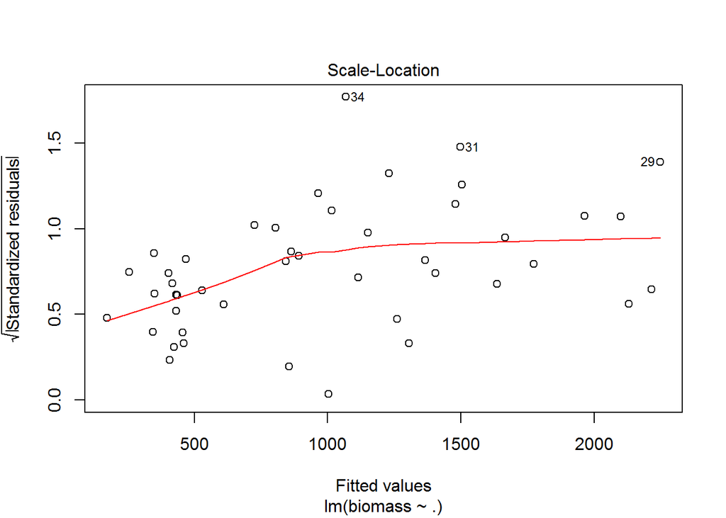

```r
plot(g, which = 3)
```

```r
summary(lm(abs(residuals(g)) ~ fitted(g)))
```

```
##
## Call:
## lm(formula = abs(residuals(g)) ~ fitted(g))
##
## Residuals:
##     Min      1Q  Median      3Q     Max
## -258.37  -95.72  -35.30   40.67  794.79
##
## Coefficients:
##             Estimate Std. Error t value Pr(>|t|)
## (Intercept) 89.69812   55.03469    1.63   0.1104
## fitted(g)    0.11958    0.04744    2.52   0.0155 *
## ---
## Signif. codes:  0 '***' 0.001 '**' 0.01 '*' 0.05 '.' 0.1 ' ' 1
##
## Residual standard error: 186.7 on 43 degrees of freedom
## Multiple R-squared:  0.1287, Adjusted R-squared:  0.1085
## F-statistic: 6.353 on 1 and 43 DF,  p-value: 0.01551
```

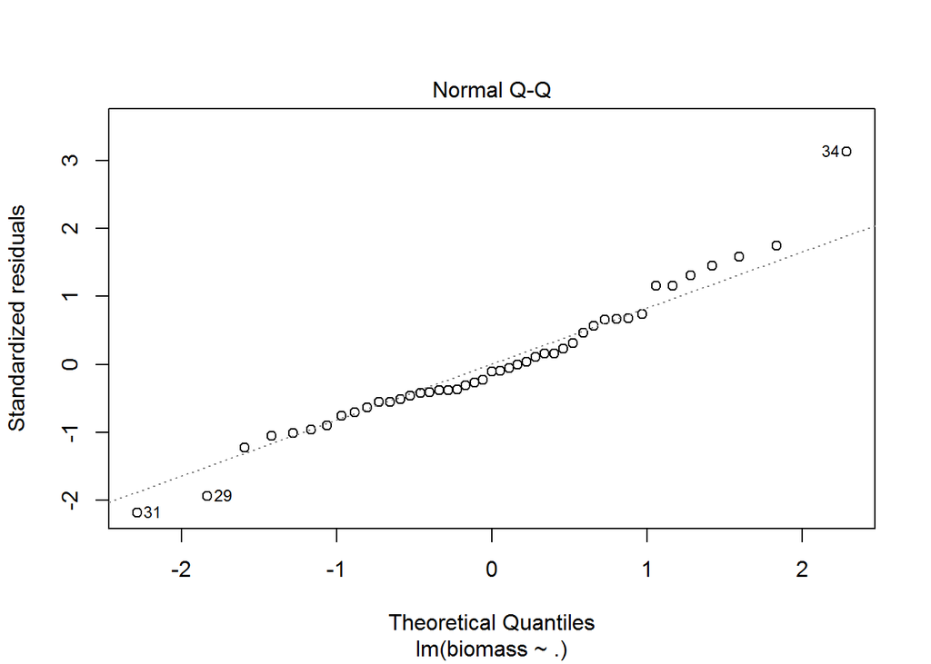

```r
plot(g, which = 2)
```

```r
shapiro.test(residuals(g))
```

```
##
##  Shapiro-Wilk normality test
##
## data:  residuals(g)
## W = 0.94494, p-value = 0.03277
```

En el primer gràfic sembla que un conjunts de punts no tenen residus aleatoris. A més, s’ha obtingut un p-valor de 0.01551, per la qual cosa es confirma que existeix un problema d’heterocedasticitat.

També, el el test de normalitat de Shapirho s’ha obtingut un p-valor menor que 0.05, per la qual cosa rebutgem normalitat.

Mirem si hi ha outliers:

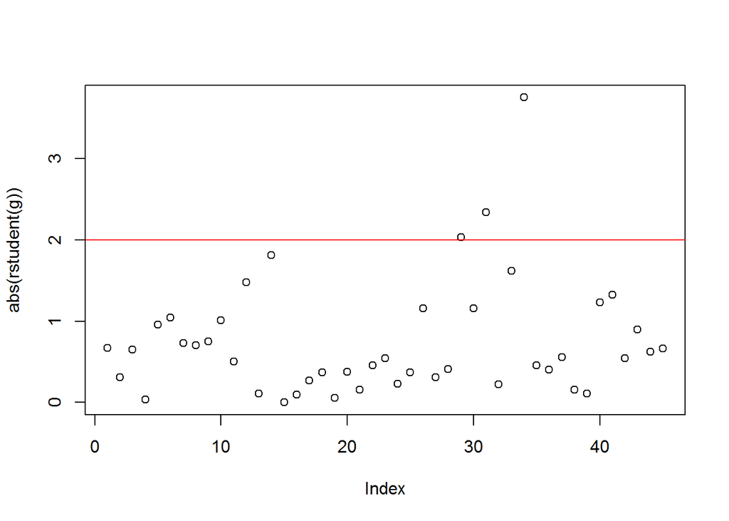

```r
plot(abs(rstudent(g)))
abline(h = 2, col = "red") # fixar la linea segons veiem
```

```r
which(abs(rstudent(g)) > 2)
```

```
## 29 31 34
## 29 31 34
```

##### E2. Distàncies de Cook:

```r
C <- cooks.distance(g)
n <- nrow(linthurst)
k <- length(g$coefficients)
ptall <- 4/(n-k-2)

which (C > ptall)
```

```
##  5 41
##  5 41
```

Observem en el següent gràfic de bombolles amb les distàncies de Cook com els punts 5 i 41 són punts influents.

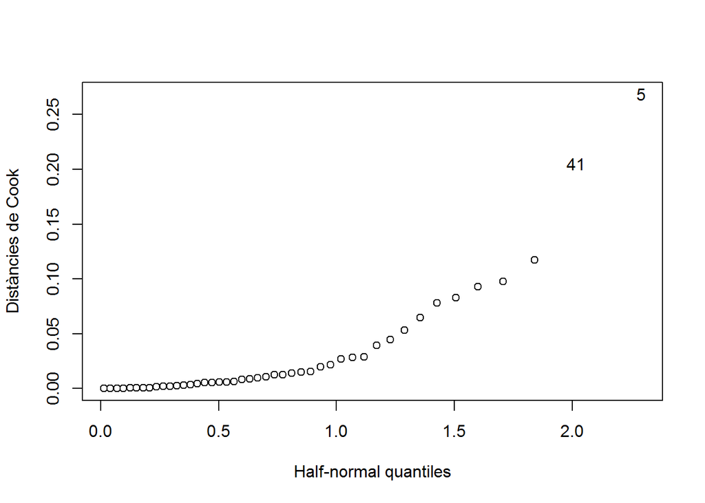

```r
library(faraway)
halfnorm(cooks.distance(g), 2, ylab = "Distàncies de Cook")
```

## PROBLEMA 3

### APARTAT A

##### A1. Matriu de correlacions:

```r
cor(linthurst[,-1])
```

```
##                   H2S    salinity         Eh7          pH         BUF
## H2S       1.000000000  0.09580885  0.39965489  0.27352903 -0.37383137
## salinity  0.095808846  1.00000000  0.30929922 -0.05133280 -0.01253342
## Eh7       0.399654889  0.30929922  1.00000000  0.09401821 -0.15308284
## pH        0.273529029 -0.05133280  0.09401821  1.00000000 -0.94637154
## BUF      -0.373831370 -0.01253342 -0.15308284 -0.94637154  1.00000000
## P        -0.115394148 -0.18567773 -0.30543134 -0.40137180  0.38293556
## K         0.068962897 -0.02063286  0.42261051  0.01922804 -0.07024704
## Ca        0.093307112  0.08797761 -0.04212099  0.87797818 -0.79107974
## Mg       -0.107821769 -0.01004276  0.29850251 -0.17614751  0.13045912
## Na       -0.003762818  0.16226567  0.34246269 -0.03771997 -0.06071412
## Mn        0.141540958 -0.25358394 -0.11125483 -0.47514280  0.42035664
## Zn       -0.272397809 -0.42083353 -0.23200548 -0.72216711  0.71468318
## Cu        0.012719279 -0.26600362  0.09454352  0.18135418 -0.14315285
## NH4      -0.426213001 -0.15683469 -0.23896605 -0.74595877  0.84948759
##                    P           K          Ca          Mg           Na
## H2S      -0.11539415  0.06896290  0.09330711 -0.10782177 -0.003762818
## salinity -0.18567773 -0.02063286  0.08797761 -0.01004276  0.162265666
## Eh7      -0.30543134  0.42261051 -0.04212099  0.29850251  0.342462687
## pH       -0.40137180  0.01922804  0.87797818 -0.17614751 -0.037719968
## BUF       0.38293556 -0.07024704 -0.79107974  0.13045912 -0.060714117
## P         1.00000000 -0.22647271 -0.30669171 -0.06323688 -0.163227625
## K        -0.22647271  1.00000000 -0.26520634  0.86224465  0.792095939
## Ca       -0.30669171 -0.26520634  1.00000000 -0.41844612 -0.248186547
## Mg       -0.06323688  0.86224465 -0.41844612  1.00000000  0.899469916
## Na       -0.16322762  0.79209594 -0.24818655  0.89946992  1.000000000
## Mn        0.49541023 -0.34745478 -0.30898479 -0.21938970 -0.310061415
## Zn        0.55740692  0.07360920 -0.69986624  0.34521697  0.117046932
## Cu       -0.05313661  0.69305055 -0.11224676  0.71206868  0.560069457
## NH4       0.48973876 -0.11758057 -0.58260897  0.10822612 -0.107024306
##                  Mn         Zn          Cu         NH4
## H2S       0.1415410 -0.2723978  0.01271928 -0.42621300
## salinity -0.2535839 -0.4208335 -0.26600362 -0.15683469
## Eh7      -0.1112548 -0.2320055  0.09454352 -0.23896605
## pH       -0.4751428 -0.7221671  0.18135418 -0.74595877
## BUF       0.4203566  0.7146832 -0.14315285  0.84948759
## P         0.4954102  0.5574069 -0.05313661  0.48973876
## K        -0.3474548  0.0736092  0.69305055 -0.11758057
## Ca       -0.3089848 -0.6998662 -0.11224676 -0.58260897
## Mg       -0.2193897  0.3452170  0.71206868  0.10822612
## Na       -0.3100614  0.1170469  0.56006946 -0.10702431
## Mn        1.0000000  0.6033230 -0.23346835  0.52702068
## Zn        0.6033230  1.0000000  0.21210248  0.72067927
## Cu       -0.2334684  0.2121025  1.00000000  0.01365659
## NH4       0.5270207  0.7206793  0.01365659  1.00000000
```

```r
which(abs(cor(linthurst[,-1])) > 0.7)
```

```
##  [1]   1  16  31  46  47  50  54  56  60  61  64  68  70  76  91  93  94
## [18] 102 103 106 119 121 122 125 133 135 136 151 158 159 166 168 177 181
## [35] 186 187 194 196
```

##### A2. Factors d’inflació:

```r
library(faraway)
vif(g)
```

```
##       H2S  salinity       Eh7        pH       BUF         P         K
##  3.027456  3.387615  1.977447 62.080846 34.431748  1.895804  7.367110
##        Ca        Mg        Na        Mn        Zn        Cu       NH4
## 16.662146 23.764229 10.351043  6.185628 11.626479  4.829203  8.376506
```

```r
which(vif(g) >4)
```

```
##  pH BUF   K  Ca  Mg  Na  Mn  Zn  Cu NH4
##   4   5   7   8   9  10  11  12  13  14
```

Hi ha 10 factors d’inflació de la variància de les regressores superiors a 4.

## PROBLEMA 4

Obtenció de les dades:

```r
library(faraway)
data("globwarm")
```

### APARTAT A

##### A1. Model de regressió.

```r
g <- lm(nhtemp ~ wusa + jasper + westgreen + chesapeake + tornetrask + urals + mongolia + tasman + year,data=globwarm)

RESI1 <- residuals(g)
```

##### A2. Gràfic de dispersió amb els residus per a cada any.

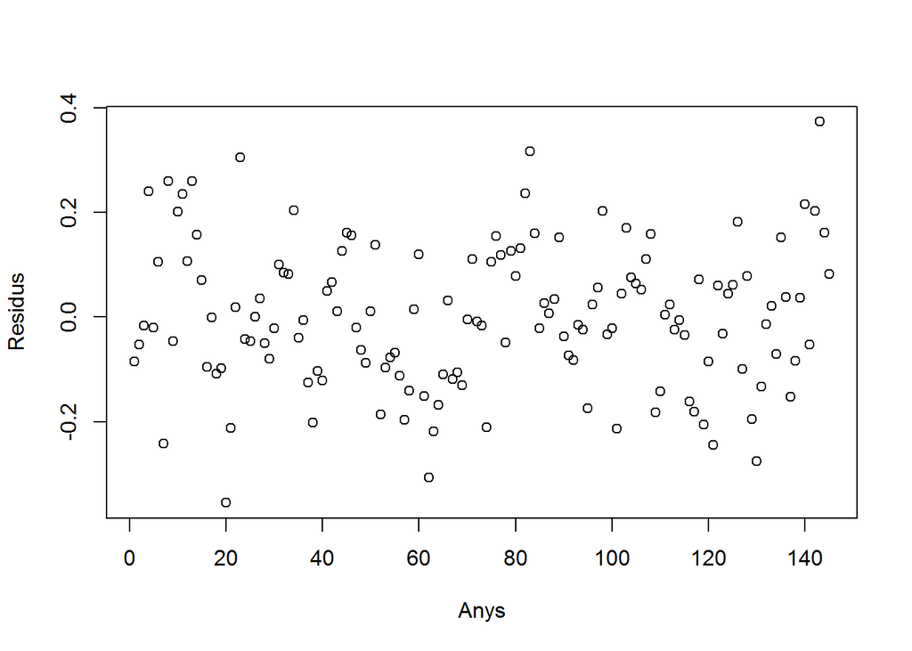

```r
plot(RESI1, xlab="Anys", ylab= "Residus")
```

Nomes es tenen els residus dels anys 1856 fins al 2000, ja que del 1000 al 1855 no es té informació sobre la variable resposta nhtemp. S’observa en el gràfic com el residus estan força aleatoritzats. Tots els punts estan dispersos per igual en el gràfic, sense seguir cap patró.

##### A3. Gràfic de dispersió amb la funció LAG.

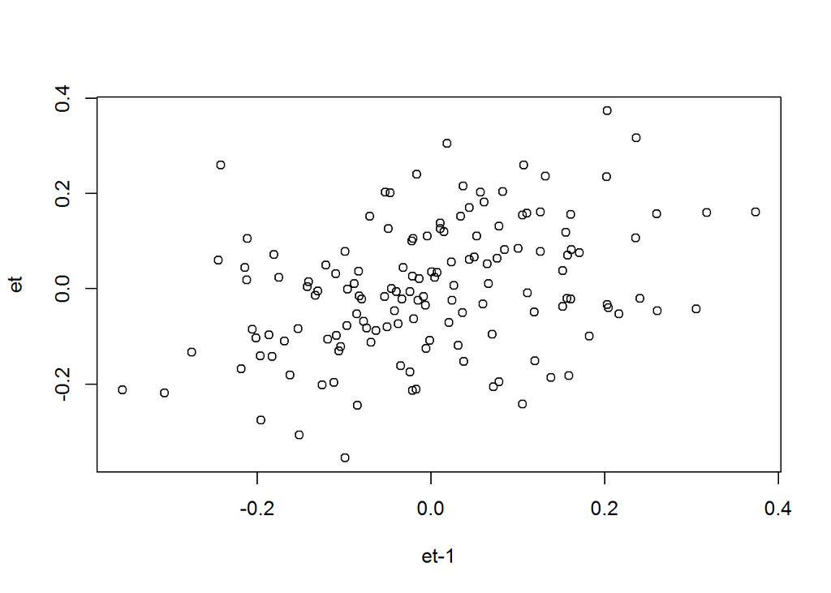

```r
LAG <- function(x) c(NA,x[-length(x)])

plot(LAG(RESI1), RESI1, xlab="et-1", ylab= "et")
```

Ara es veu en el gràfic una relació lineal: quan major és $e_t-1$, major és també $e_t$.

```r
g_e <- lm(RESI1 ~ LAG(RESI1))
g_e # Coeficients de la recta
```

```
##
## Call:
## lm(formula = RESI1 ~ LAG(RESI1))
##
## Coefficients:
## (Intercept)   LAG(RESI1)
##   0.0008013    0.3622981
```

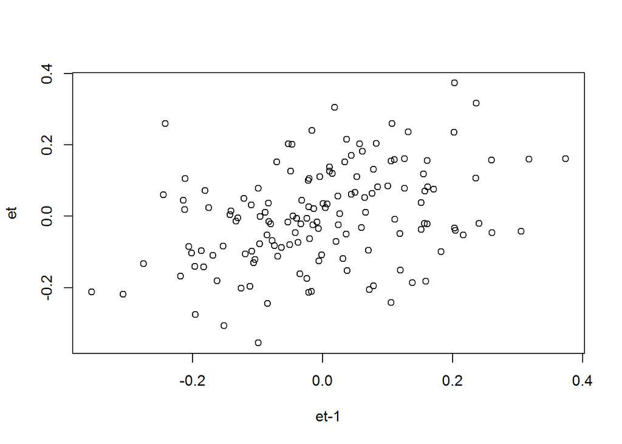

```r
plot(LAG(RESI1), RESI1, xlab="et-1", ylab= "et")
```

### APARTAT B

```r
library(car)
durbinWatsonTest(RESI1)
```

```
## [1] 1.272036
```

Veiem com si hi ha una mica de correlació positiva (valor entre 0 i 2).

### APARTAT C

```r
dades <- globwarm[857:1001, -10]

# Variable transformadora de la variable resposta:
Y_fd <-  nhtemp-LAG(nhtemp)

# Variables transformadores de les var regressores:
X_fd1 <-  globwarm$wusa-LAG(globwarm$wusa)
X_fd2 <-  globwarm$jasper-LAG(globwarm$jasper)
X_fd3 <-  globwarm$westgreen-LAG(globwarm$westgreen)
X_fd4 <-  globwarm$chesapeake-LAG(globwarm$chesapeake)
X_fd5 <-  globwarm$tornetrask-LAG(globwarm$tornetrask)
X_fd6 <-  globwarm$urals-LAG(globwarm$urals)
X_fd7 <-  globwarm$mongolia-LAG(globwarm$mongolia)
X_fd8 <-  globwarm$year-LAG(globwarm$year)
```

### APARTAT D

```r
library(orcutt)
cochrane.orcutt(g)
```

```
## Cochrane-orcutt estimation for first order autocorrelation
##
## Call:
## lm(formula = nhtemp ~ wusa + jasper + westgreen + chesapeake +
##     tornetrask + urals + mongolia + tasman + year, data = globwarm)
##
##  number of interaction: 4
##  rho 0.362701
##
## Durbin-Watson statistic
## (original):    1.27204 , p-value: 8.524e-08
## (transformed): 2.05773 , p-value: 3.274e-01
##
##  coefficients:
## (Intercept)        wusa      jasper   westgreen  chesapeake  tornetrask
##  -15.191328   -0.135666    0.012482    0.066343    0.007852    0.047921
##       urals    mongolia      tasman        year
##    0.092636   -0.148646    0.004817    0.007866
```

La constant de regressió (intercept) segons el procediment de Cochrane-Orcutt és -15.191328.